[figure not shown]

# 8. Design and implementation of user experiments

### Andrej Košir, Lucami, Fe

#### Contact: andrej.kosir@fe.uni-lj.si

#### Zoom https://uni-lj-si.zoom.us/J/8638167479

[figure not shown]

8. Design and implementation of user experiments

### Aim of chapter and learning outcomes

#### Objective:

The goal of the chapter is to understand the importance of user experiments, to learn the main challenges and their solutions in the design, implementation and analysis of user experiments.

#### learning outcomes

To get to know the basics of experiments. To understand the processing process of experiments. Understanding statistical testing related to user experiments.

1

[figure not shown]

8. Design and implementation of user experiments

Content

## Content

8.1. Introduction

■ The problem and importance of user tests*

■ What is an experimental design*

■ Experimental and non-experimental designs*

8.2. Elements of statistics

■ Introductory Example: Discovering a fair coin

■ Null hypothesis, p-value and risk level $ \alpha $*

■ Errors and statistical power*

■ The size of the effect

■ Statistical Test: T-Test

■ Statistical Test: Stake Test

8.3.Elements of experimental designning

■ Population and representativeness of the sample

■ Determining sample size (number of test persons)

■ Experiment scheme selected: Annovo design*

■ Selected Experiment Scheme: Latin Square design

8.4.Planning a study / experiment

■ Introduction

■ Step 1: Determining the goals of an experiment*

■ Step 2: Criteria Functions - Performance Dimensions*

■ Step 3: Determination of factors*

■ Step 4: Determining an experimental scenario*

■ Step 5: Determination of criteria and selection of test persons*

■ Step 6: Implementing an environmental experiment and execution*

■ Step 7: Result analysis: measurement characteristics*

■ Step 8: Result analysis: Hypothesis testing*

2

[figure not shown]

8. Design and implementation of user experiments

8. 1. Introduction

## ■ The problem and importance of user testing

### Illustration problem: Is the communication device important in the quality of the two talk?

Theories cannot answer this question. **The only option is user testing.**.

Why:

- in human behavior is **a real coincidence** (not just a manjek information);
- there are no good simulators of human behavior;

#### interpretation of results

Let us take an attempt with enough users and find that the measured success success of $ C $ conversation, according to users, is the following:

Varinata results 1:

| Device | Performance $ O $ |
| --- | --- |
| PC | $ 2.1 $ |
| Alexa Echo | $ 4.2 $ |

Varinata results 2:

| Device | Performance $ O $ |
| --- | --- |
| PC | $ 3.7 $ |
| Alexa Echo | $ 3.8 $ |

##### Problem: Is the difference between $3.7$ and $3.8$ true (echo is better than PCA) or just a chance of coincidence?

- Even if there is no real difference, we never get the same value!
- The term **true** means that the difference would consistently maintain through several repetitions of attempts!

Solution: **Statistical testing hypotheses**

3

[figure not shown]

8. Design and implementation of user experiments

8. 1. Introduction

## ■ What is an experimental design

The elements of an experimental design are as follows:

##### 1. Dependent variable (response) $c$:

Criteria function, performance indicator, etc. that gives the main result.In our case, the success of the conversation.

##### 2. Controlled (i) factor (s) $ f_e $:

Independent variables that are controlled ** in an attempt **.In our case, this is a communication device, so it has a controlled value factor (level) {PC, Alexa Echo}.

##### 3. Nuisance factors:

These are undesirable effects on an experimental result that are inevitable.We want to neutralize them in many ways;

#### 4. Input noise $\varepsilon$:

This is a noise that introduces unknown disturbing factors and real noise that comes from randomness of human behavior, the noise of sensors, etc.

[figure not shown]

##### Def.: The Design of Experiment (DOE) is an effective process for planning experiments that involves the choice of criterion, planning of procedures in the experiment, and the plan to analyze the results obtained that lead to valid and objective conclusions.

We have:

- Procedures also include determining criteria for selection of close persons, a strain number of test persons, etc.Also include a detailed plan of the experiment
- Before trying to produce **statistical experimental design** for data analysis to answer the questions asked
- Each experiment covers only part of the area - it is representative only for the area represented by the input (test persons).they represent;

4

[figure not shown]

8. Design and implementation of user experiments

8. 1. Introduction

## ■ Experimental and non-experimental designs

#### Experimental design

This is an attempt (with end users) where **compare** two or more variants

- user groups
- a system variant
- situations
- ...  
  with each other.We need to control at least one of the ** factors **, that is, to control its value.

It is important that other **factors** (effects on the result) are properly treated.

#### Non-experimental design

This is an attempt at which we observe the results ** without the control of factors ** and in the manner of control of the factors in the course of the course ** we do not interfere. **

5

[figure not shown]

8. Design and implementation of user experiments

8.2.Elements of statistics

## 8.2. Elements of statistics

■ Introductory Example: Discovering a fair coin

■ Null hypothesis, p-value and risk level $\alpha$*

■ Errors and statistical power*

■ The size of the effect

■ Statistical Test: T-Test

■ Statistical Test: proportion test

7

[figure not shown]

8. Design and implementation of user experiments

8.2.Elements of statistics

## ■ Introductory example: Discovering a fair coin

#### Problem

We want to find out if the coin is level (honest).

### hypothesis and attempt

Assume the coin is honest.This means that the likelihood of falling the coat of arms is equal to $ P [G] = $ 0.5, that is both sides are equally likely.

We make an experiment by throwing a $n = 1000$ times and recording how many times the coat of arms has fallen.Let's take it to be the results

| Trial | Outcome |
| --- | --- |
| 1 | $482$ |
| 2 | $612$ |
| 3 | $452$ |
| 4 | $420$ |
| 5 | $20$ |

#### Interpretation of the result and conclusion

Will the result for a fair coin be exactly the expected value $k=P[G]\cdot n = 0.5\cdot 1000 = 500$? No, because there is a chance in between.

Where is the limit of deviation from $500$?

Statistical testing: the limit is a deviation of $31$, that is, between $469$ and $531$, it is OK, otherwise it is not.

Why?

**At this limit, the probability (p value) that the result of the experiment is random in the case of a fair coin is so small (risk level $\alpha$) that we no longer accept it**.

8

[figure not shown]

```
Lower critical value: 531.0
Upper critical value: 469.0
```

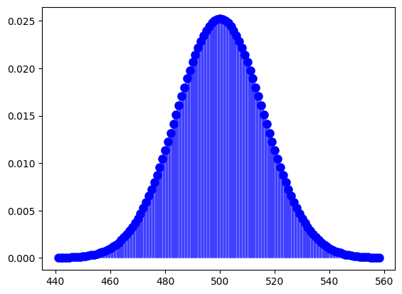

```python
# Title: Distribution and risk level
# Goal: to understand setting the critical value of the deviation


import numpy as np
from scipy.stats import binom
import matplotlib.pyplot as plt


# Plot binomial distribution
fig, ax = plt.subplots(1, 1)

n = 1000
p = 0.5
x = np.arange(binom.ppf(0.0001, n, p), binom.ppf(0.9999, n, p))
ax.plot(x, binom.pmf(x, n, p), 'bo', ms=8, label='binom pmf')
ax.vlines(x, 0, binom.pmf(x, n, p), colors='b', lw=5, alpha=0.5)


# Read critical value
alpha = 0.05
q1 = 1 - alpha/2
q2 = alpha/2
print ('Lower critical value:', binom.ppf(q1, n, p, loc=0))
print ('Upper critical value:', binom.ppf(q2, n, p, loc=0))
```

```python
# Title: Perform statistical test: binomial test
# Binomial test for tossing coin


import scipy as sc
# Generate data


# Get p-value
p_in = 0.5

k = 480
x = [k, n-k]
p_val = sc.stats.binom_test(x, p=p_in)
print ('p value for k =', k, 'is: ', p_val)

k = 470
x = [k, n-k]
p_val = sc.stats.binom_test(x, p=p_in)
print ('p value for k =', k, 'is: ', p_val)

k = 465
x = [k, n-k]
p_val = sc.stats.binom_test(x, p=p_in)
print ('p value for k =', k, 'is: ', p_val)

k = 420
x = [k, n-k]
p_val = sc.stats.binom_test(x, p=p_in)
print ('p value for k =', k, 'is: ', p_val)

k = 20
x = [k, n-k]
p_val = sc.stats.binom_test(x, p=p_in)
print ('p value for k =', k, 'is: ', p_val)
```

[output not shown]

8. Design and implementation of user experiments

8.2.Elements of statistics

■ Null hypothesis, p-value and risk level $\alpha$

For example, we define:

#### Null hypothesis $H_0$

Hypothesis $H_0$ assumes that **there is no effect**, i.e. that there is no difference between groups, devices, algorithms, that the coin is fair, etc.

#### p-value:

$$ p = P[\text{The result of the experiment is one or more times the result of the experiment away from the null hypothesis $H_0$}\big|_{H_0}]. $$

#### Risk level $\alpha$ and conclusion about the hypothesis

We choose a risk level $\alpha$, typically $\alpha=0.05$, and it is the lower bound of the probability that we still accept when interpreting the experiment. We conclude as follows:

- if $p<\alpha$, we reject the hypothesis $H_0$;
- if $p\geq\alpha$, the hypothesis $H_0$ is accepted;

If the null hypothesis $H_0$ is rejected, the deviation (difference) is **statistically significant**.

#### Alternative hypothesis, one- and two-sided test

It is also essential to determine the alternative to the null hypothesis, which directly affects the determination of the p value.

Alternative hypotheses can be

- $H_1$ is the negation of $H_0$: since this is usually of the form $H_1=[X\ne x_0]$, this is a two-sided test
- $H_1$ is only part of the negation of $H_0$: since this is usually of the form $H_1=[X < x_0]$ or $H_1=[X > x_0]$, this is a one-sided test

9

[figure not shown]

8. Design and implementation of user experiments

8.2.Elements of statistics

## ■ Errors and statistical power

### Errors of Statistical Testing

When concluding a Null hypothesis based on an experiment, an error may occur:

|  | $\hat{H_0}$ | $\neg\hat{H_0}$ |
| --- | --- | --- |
| $H_0$ | OK | err. I. |
| $\neg H_0$ | err. II. | OK |

Errors **cannot be avoided**.

#### Error I. Type

The likelihood of mistakes I. type is $$ P[err. I.] = \alpha, $$ So flat rate risk $ \alpha $.This probability is surprisingly **independent of the sample size**.

##### Error II.types

The likelihood of errors II.the species is $$ P[nap.II.] = \beta $$

### Statistical power

Statistical power is the likelihood of Null hypothesis of $ H_0 $ reject when this one does not hold: $$ \text{pw} = 1- \beta = p [\neg \hat {H_0} \vert _ {\neg H_0}] $$

Intuitive speaking, it is a sensitivity of a statistical test in the sense that it refuses a hypothesis when it does not hold even when the deviation from the Null hypothesis is low.

It depends on the size of the sample and we determine the sample size.

We know apriori (in advance - for sample size) and posteriori (then - tested) statistical power.

10

[figure not shown]

8. Design and implementation of user experiments

8.2.Elements of statistics

## ■ Effect size

Effect size (es) is the size of a normalised deviation from the Null hypothesis of $H_0$ that definitely has the size of $ 0 effect.For each test, the size of the effect is specified specific:

- T -Test - normalised difference of means $\text{es}=\frac{\overline{x}_1 - \overline{x}_2}{\sigma_p}$
- correlation: $ \text{es} = | r | $
- ...

We usually set boundaries for small, medium and high effect size.

11

[figure not shown]

8. Design and implementation of user experiments

8.2.Elements of statistics

## ■ Statistical Test: T-Test

#### Description

T-test tests the differences of average of two normally distributed variables $ X_1 $ and $ x_2 $.

#### Null hypothesis $ H_0 $

The Null hypothesis is $$ H_0 = [E (X_1) = E (X_2)], $$ where $ E(X) $ expected value of a random variable $X$.

#### Assumptions

A random variables $ X_1 $ and $ X_2 $ are distributed normally. Verified by Lilliefors test.

#### Variants

There are

- T-test for dependent patterns: variables $ X_1 $ and $ X_2 $ represent the same object (person, ...) that is measured at different times;
- T-test for independent patterns: variables $ X_1 $ and $ X_2 $ represent different objects;

#### Experemental data and P-value

Experimental data is a sample of random variables $ X_1 $ (ie $ x_{11}, \ldots, x_{1n} $) and $x_2 $ (ie $x_{21}, \ldots, x_{2n} $). The test statistics are distributed according to Student's $t$ distribution. See the case below to determine p values.

12

[figure not shown]

```python
## Title: T-test example
# Goal: to understand significant difference between means
# Hint: change mu1 and mu2 to see when the difference is significant


# Data generation
import numpy as np
from scipy import stats
import random


## Independent samples

# Generate data
random.seed()
mu1, sg1 = 1, 0.8 # Params of normal distributions
mu2, sg2 = 1.2, 0.8 # Params of normal distributions
n1, n2 = 100, 120
x1_lst = np.zeros(n1)
x2_lst = np.zeros(n2)

la = 10.0
for i in range(n1):
    x1_lst[i] = random.gauss(mu1, sg1) + la*random.uniform(mu1-sg1, mu2+sg1)
for i in range(n2):
    x2_lst[i] = random.gauss(mu2, sg2) + la*random.uniform(mu2-sg2, mu2+sg2)


# Test are assumptions true
a1, s1 = np.mean(x1_lst), np.std(x1_lst)
a2, s2 = np.mean(x2_lst), np.std(x2_lst)
st1, p1 = stats.kstest((x1_lst-a1)/s1, 'norm')
st2, p2 = stats.kstest((x2_lst-a2)/s2, 'norm')
print ('X1 Normal?, p=', p1)
print ('X2 Noirmal?, p=', p2)

# Get p-value
t_stat, p_val = stats.ttest_ind(x1_lst, x2_lst)
print ('Independent t-test, p-val =', p_val)



## Dependent samples = paired test

# Generate data
random.seed()
mu1, sg1 = 1, 0.8
mu2, sg2 = 1.2, 0.8
n = 100
x1_lst = np.zeros(n)
x2_lst = np.zeros(n)

for i in range(n1):
    x1_lst[i] = random.gauss(mu1, sg1)
    x2_lst[i] = random.gauss(mu2, sg2)

# Get p-value
t_stat, p_val = stats.ttest_rel(x1_lst, x2_lst)
print ('Dependent t-test, p-val =', p_val)
```

```
X1 Normal?, p= 0.6019404169592835
X2 Noirmal?, p= 0.1685282201649504
Independent t-test, p-val = 0.0016267854549518969
Dependent t-test, p-val = 0.0014533149840154351
```

8. Design and implementation of user experiments

8.2.Elements of statistics

## ■ Statistical test: Stake test test

#### Description

The proportion test is tested or experimentally obtained is equal to the known value of $p_0$.

#### Null hypothesis $ H_0 $

The Null hypothesis is $$ H_0 = [k/n = p_0], $$ where $ p_0 $ is known share and $ k/n $ experimentally obtained share ($n$ is the number of trials, $k$ number of successful trials).

#### Assumptions

There are no assumptions.

#### Experement data and P-value

Experimental da is obtained as $k$ and $n$.

13

[figure not shown]

```python
## Tite: Test of proportions
# Goal: the implementations of the test of proportions
# Hint: change p1 to see when the deviation from p0 is significant



# Data generation
import numpy as np
from scipy import stats
import random


# Generate data
random.seed()
p0 = 0.32
p1 = 0.4
n = 100
x_lst = np.zeros(n)

for i in range(n):
    if random.random() < p1:
        x_lst[i] = 1

# Get p-value
n = len(x_lst)
k = np.sum(x_lst)
p_val = stats.binom_test(k, n=n, p=p0)
print ('Proportion test, p-val =', p_val)
```

```
Proportion test, p-val = 0.02382169586848038
```

8. Design and implementation of user experiments

8.3.Elements of experimental design

## 8.3. Elements of experimental design

■ Population and representativeness of the sample

■ Determining sample size (number of test persons)

■ Experiment scheme selected: Annovo design*

■ Selected Experiment Scheme: Latin Square design

14

[figure not shown]

8. Načrtovanje in izvedba uporabniških poskusov

8.3.Elements of experimental design

## ■ Population and representativeness of the sample

#### Steps determining

1. Describe the population according to the segments and which homogeneous segment you address
2. Define the characteristics of the pattern through
   - inclusion criteria
   - excluding criteria
3. Sampling: What is determined and what is random?
   - determine what suits the goal
   - everything else randomly

#### Tips

- The population should match your developmental / research question
- Non -homogeneous population makes it impossible to interpret your attempt.The population and pattern should be homogeneous
- If random sampling is not feasible, consider the population definition again

15

[figure not shown]

8. Design and implementation of user experiments

8.3.Elements of experimental design

## ■ Determining the sample size (number of test subjects)

#### Important:

- completely different for 1. hypothesis testing and 2. parameter estimation
- for each task, the sample size is determined separately

#### Hypothese testing

A priori power analysis:

- effect size $\text{ef}$:
- t-test: $ef=\frac{\overline{x}_1-\overline{x}_2}{\sigma_p}$
- correlation: $ef=|r|$
- ...
- remember:
- $ef < 0.3$: small
- $ef \in [0.3, 0.5]$: medium
- $ef > 0.5$: large
- Statistical power = $Pr[\hat{\neg H_0}|_{\neg H_0}] = f(n, \text{ef})$, use G*Power to estimate the size of $n$

Link to the tool [G*Power](https://www.psychologie.hhu.de/arbeitsgruppen/allgemeine-psychologie-und-arbeitspsychologie/gpower).

Using GPower: for the difference of means of the independent variable (also ANOVA) we choose

- Test family = t-test
- Two groups of users:
- Normal distribution y: Statistical tet = Means: Difference between two independent means (two groups)
- Second distribution y: Statistical tet = Means: Wilcooxon-Mann-Whitney test (two groups)
- Two versions of the technology:
- Normal distribution y: Statistical tet = Means: Difference between two independent means (matched pairs)
- Second distribution y: Statistical tet = Means: Wilcooxon-Mann-Whitney test (matched pairs)
- Types of power analysis: A priors: ...

#### Parameter estimation

The input is the upper bound on the size of the confidence interval ($Pr[x\in CI]=\alpha$) $$ CI = [\hat{\overline{x}} - z_\alpha \frac{\hat{\sigma}}{\sqrt{n}}, \hat{\overline{x}} - z_\alpha\frac{\hat{\sigma}}{\sqrt{n}}] $$ and $$ |CI| = 2 z_\alpha\frac{\hat{\sigma}}{\sqrt{n}} \leq \Delta P, $$ where $z_\alpha = 1.96$, and $$ 4 z_\alpha^2 \frac{\hat{\sigma}^2}{\Delta P^2} < n. $$

16

[figure not shown]

8. Design and implementation of user experiments

8.3.Elements of experimental designning

## ■ Selected experimental design: ANOVA design

$\def\ovr#1{{\overline{#1}}}$

#### Controlled and confounding factors

Types:

- fixed effect: the experimental factor is controlled
- random effect: the value of the experimental factor is random
- mixed effect model: we have factors with fixed and random effects

Value pool:

- discrete values
- two or more values

#### Conditions

The variables are normally distributed.

#### Selected terminology

###### Regarding the control of factors

- fixed effect: the experimental factor is controlled
- random effect: the value of the experimental factor is random
- mixed effect model: we have factors with fixed and random effects

###### Regarding the number of factors

- one way: the design has one controlled factor
- two way: the design has two controlled factors

#### Null hypothesis and test

We only cover the variant **one factor** with **fixed effect**.

Null hypothesis: $$ H_{0} = [\ovr{y}_{G_1} = \cdots = \ovr{y}_{G_I}], $$

Test: F-test.

Here:

$\def\o#1{{\overline{#1}}}$ $\def\SS{{\text{SS}}}$ $\def\Var{{\text{Var}}}$

###### Notations

- $n$ is the number of times the experiment is run at each value of the controlled factor $F_e$.
- $a$ is the number of values of the controlled factor $F_e \in \{1, 2, \ldots, a\}$
- $y_{ij}$ is the $j$-th result of the experiment, $i=1,\ldots, n$, for the factor value $F_e=i$
- $y_{i.} = \sum_{j=1}^n y_{ij}$ sums over trials
- $\o{y}_{i.} = y_{i.}/n$ average over trials
- $y_{.j} = \sum_{i=1}^a y_{ij}$ sums over factor values
- $\o{y}_{.j} = y_{.j}/n$ average over factor values
- $y_{..} = \sum_{i,j} y_{ij}$ total sum
- $\o{y}_{..} = y_{..}/n$ total average

##### Sums of squares

- total sum of squares $$ \SS_{tot} = \sum_{i=1}^a \sum_{j=1}^n (y_{ij} - \o{y_{..}})^2 $$
- sum of squares of the factor $$ \SS_{trt} = n \sum_{i=1}^a (\o{y}_{i.} - \o{y_{..}})^2 $$
- Then the total sum of squares can be divided into the sum of the factor and the errors $\SS_{err}$, i.e. $$ \SS_{tot} = \SS_{trt} + \SS_{err} $$

#### Variants

- one way: the design has one controlled factor
- two way: the design has two controlled factors

17

[figure not shown]

8. Design and implementation of user experiments

8.3.Elements of experimental designning

## ■ Selected experimental design: Latin square design

$\def\ovr#1{{\overline{#1}}}$

A Latin square design of dimensions $N\times N$ (typically $N$ between $2$ and $4$) is an experimental design with one controlled factor and two confounding factors whose effect we want to eliminate.

A Latin square is a square design in which the values of the controlled factors $A, B, C, \ldots$ appear exactly once in each row and in each column. An example of a square for $3\times 3$ is

|  | $F_{11}$ | $F_{12}$ | $F_{13}$ |
| --- | --- | --- | --- |
| $F_{21}$ | A | B | C |
| $F_{22}$ | C | A | B |
| $F_{23}$ | B | C | A |

#### Controlled and Disturbing Factors

The set of values for all (controlled and disturbing factors) is exactly $N$

- Controlled factor: $F\in \{A, B, C\}$
- Two disturbing factors: $F_1$ and $F_2$

#### Example N=2

- Research question: does gender influence the experience of the quality of a conversation with a smart system?
- Null hypothesis $H_0 = [\text{Gender has no effect on the experience of the quality of the dialogue with the smart system.}]$
- Controlled factor: $F\in \{\text{female, male}\}$
- Disruptive factor Experience with technology": $F_1\in \{\text{small, large}\}$
- Disruptive factor Affective state: $F_2\in \{\text{negative, positive}\}$

#### Conditions

Conditions on minimum sample size.

#### Null hypothesis and test

Null hypothesis: $$ H_{0} = [\text{controlled factor has no effect}] $$

Test: F-test.

17

[figure not shown]

```python
## Title: ANOVA design
# Goal: undesrtand the implementaiton of the ANOVA experimental design
# Hint: direct implementation

import numpy as np
import pandas as pd
import scipy.stats as stats


# Experiment:
#  Users were testing an app in three versions (G=1, G=2, G=3) and reported experinece on a scale denoted by y


# Load data
post_fn = 'https://raw.githubusercontent.com/andrejkk/UPK_DataImgs/master/ANOVAtestData.csv'
data_df = pd.read_csv(post_fn, sep=';', encoding='utf8')


# stats f_oneway functions takes the groups as input and returns ANOVA F and p value
dataG1 = data_df[data_df['G']==1]['y']
dataG2 = data_df[data_df['G']==2]['y']
dataG3 = data_df[data_df['G']==3]['y']
fvalue, pvalue = stats.f_oneway(dataG1, dataG2, dataG3)
print('p-value = ', pvalue)

# Result: since p = 1.008 e-08 < 0.05, H0 is rejected and we conclude there is an effect
```

```
p-value =  1.008419118933826e-08
```

8. Design and implementation of user experiments

8.4.Planning a study / experiment

## 8.4. Study / Experiment design

■ Introduction

■ Step 1: Determining the objectives of the experiment

■ Step 2: Criterion functions - measures of success

■ Step 3: Choosing a statistical design and determining factors

■ Step 4: Determining the experimental scenario

■ Step 5: Determining criteria and selecting test subjects

■ Step 6: Implementing the experimental environment and conducting

■ Step 7: Analyzing the results: measurement characteristics

■ Step 8: Analyzing the results: testing the hypotheses

19

[figure not shown]

8. Design and implementation of user experiments

8.4.Planning a study / experiment

## ■ Introduction

Instructions for experiments and studies come from ** definition of Western science **:

- the result is scientific if it comes from a correct experiment
- Results can be **interpreted**
- the experiment must be reproducible
- sufficiently described
- Available test data
- Recase result matches the original experiment

20

[figure not shown]

8. Design and implementation of user experiments

8.4.Planning a study / experiment

## ■ Step 1: Determining the goals of an experiment

Experimental and observational studies have different goals

#### Aim of experimental study

The goal is to answer the **Research Question**.This is a question that we answer with the implementation of the experiment.

In our case, the research is *"Does the device (simulator or echo) affect the perceived quality of conversation?"*

#### Aim of Observational Studies

The goal of observational studies is

- Construction **models of relationships between independent and dependent variations**
- analysis
- ...

#### Study of cases and population study

Case study

- deals with a small number of cases
- Results ** are not generalizable ** on any population.

A population study

- has a population (test persons, ..) - a pattern that **represented the known population**, e.g.
- older people with cognitive problems
- Recreational athletes 18-14 years
- ...
- has a large enough pattern to make the joints valid with sufficiently likely

### in our field: experimental studies - A / B testing

21

[figure not shown]

8. Design and implementation of user experiments

8.4.Planning a study / experiment

## ■ Step 2: criteria functions - performance dimensions

#### Def.: : Performance degree is any metric that measures well enough of the system's performance that we nalize.

The measure of performance should **Measure aspects for which it is intended for**.

The performance of performance should give performance estimates which are

- Edited in size, which allows separation between better and worse variants / designs.
- have an interpretation

Performance dimensions have different sources:

- established dimensions in the area
- new structures

22

[figure not shown]

8. Načrtovanje in izvedba uporabniških poskusov

8.4.Planning a study / experiment

## ■ Step 3: Choosing a statistical design and determining factors

#### Statistical design of the experiment

We know several different designs, including:

- ANOVA
- Latin square

#### Factors

Depending on the goal of the experiment, we determine factors - **variables that affect the outcome of the study or experiment** as measured by the criterion function.

We determine factors based on knowledge of the field.

##### Factors of the experimental design

We distinguish

- controlled factors
- interfering factors

###### Factors of an observational study

There are no controlled factors in an observational study.

23

[figure not shown]

8. Design and implementation of user experiments

8.4.Planning a study / experiment

## ■ Step 4: Determine the experimental scenario

#### Def.: An experimental scenario is a scenario that is performed by test subjects in order to obtain relevant measurements and results

#### Imaginary goal of the experiment

- the goal of the experiment is **the goal that the test subjects have in mind while conducting the experiment** and not the research goal of the experiment!
- provides a **frame of reference** for the results of the experiment - measurements and answers to questions
- is directly related to
- experimental service
- experimental content

#### Guidelines for the experimental scenario

- the experimental scenario is conceivable for test subjects:
- seniors 60+ and "escape rooms" do not go together
- ...
- the experimental scenario must be simple enough that
- it can be presented with instructions
- test subjects do not experience **unplanned surprises** - every surprise destroys the test subject's frame of reference and increases the unreliability of responses (answers and psychophysiological measurements)
- clear instructions and guidelines are important, which do not lead test subjects to **surprises** during the implementation
- every **possible development of events** is a possibility for new information about the user
- e.g. the "fast-forward" option when watching a movie will tell whether the test subject has decided on it
- appropriate cognitive effort of the test subjects:
- too little: uninterested
- too much: defense mechanisms hide the results

24

[figure not shown]

8. Design and implementation of user experiments

8.4.Planning a study / experiment

## ■ Step 5: Determining criteria and selecting test subjects

#### Representativeness of results

The results of an experiment (trial) are **representative** for a given population if

- the test subjects represent all important subgroups of this population
- the sample of test subjects is large enough

#### Explicit criteria for selecting subjects - inclusion and exclusion criteria

This is a description and justification for selecting test subjects:

- description of the criteria for selecting test subjects:
- demographics: age, gender, ...
- skills with technology, ...
- ...
- how we accessed the test subjects:
- telephone
- existing registry and random selection
- criteria for the process of eliminating test subjects
- during the experiment: non-response
- after the experiment: we noticed that he did not solve the task seriously (how)
- ...

The process of selecting test subjects is a necessary condition for interpreting the results.

25

[figure not shown]

8. Design and implementation of user experiments

8.4.Planning a study / experiment

## ■ Step 6: Implementation of the experiment environment and execution

#### Implementation

- the application we are testing
- the experiment management system
- the data acquisition system: sensors, cloud, questionnaires, ...

#### Execution

- trial series for
- eliminating distracting factors for test subjects
- data acquisition test
- trial analysis of results
- execution
- post-interview

#### Depending on the nature of the experiments, we place the implementation

- in the laboratory
- on online platforms
- Amazon Mechanical Turk https://www.mturk.com/
- Clickworker https://www.clickworker.com/
- social networks

26

[figure not shown]

8. Design and implementation of user experiments

8.4.Planning a study / experiment

## ■ Step 7: Result analysis: measurement characteristics

Proof of the measurement characteristics of the instrumentation is required for the validity of the results.

See section 4.

27

[figure not shown]

8. Design and implementation of user experiments

8.4.Planning a study / experiment

## ■ Step 8: Analysis of results: model building, connection analysis, hypothesis testing

#### Observational study: model building and connection analysis

The results of an observational study provide

- **training and/or test** set for building models using machine and statistical learning.
- **data** for analyzing connections between phenomena - variables

#### Experimental design: hypothesis testing

The experimental design provides data for **hypothesis testing**

- from the **research question** we form a **working hypothesis**
- our example of a conversation with Alexa:
- research question: does the interface (Echo or simulator) affect the perception of the quality of the dialogue?
- working hypothesis: the interface affects the perception of the quality of the conversation
- based on the working hypothesis, we form a **null hypothesis**
- our example conversation with Alexa:
- null hypothesis(es) $$ H_0 = [\overline{y}_S = \overline{y}_E], $$ where $\overline{y}_S$ is the average of the results of the simulator group and $\overline{y}_E$ is the average of the results of the Echo group.

#### Example: one-way ANOVA with fixed effects

28

[figure not shown]

```python
# Define sums of squares
def get_ANOVA_SS(data_df):
    a,n = data_df.shape
    N = a*n

    y_pp = 1.0*data_df.sum().sum()
    y_ip = 1.0*data_df.sum(axis=1)

    # SS total
    SS_T = (data_df**2).sum().sum() - (y_pp**2)/N

    # SS treatment
    SS_trt = (1.0/n)*(y_ip**2).sum() - (y_pp**2)/N

    # SS error
    SS_err = SS_T - SS_trt

    # Report
    return SS_trt, SS_err, SS_T
```

```python
## Estimate quality of speech interface
# User Goal Orientation = UGO: 8 items, a = .92
# Customer Service Behaviors = CSB: 8 items, a = .89
# Speech Characteristics = SC: 5 items
# Verbosity = V: 4 items, a = .69


import numpy as np
import pandas as pd
from scipy.optimize import minimize


# @brief reshape ND array to 1D as required by binary FA
# @arg nS number of samples
# @arg nQ number of questions
def reshape_NDto1D(a_nparr, nS, nQ):
    return a_nparr.T.reshape(nS*nQ)


# @brief reshape 1D array back to ND as required by binary FA
# @arg nS number of samples
# @arg nQ number of questions
def reshape_1DtoND(a_nparr, nS, nQ):
    return a_nparr.reshape(nQ, nS).T


# @brief Get linear scores using direct optimisation.
# @arg qa_mat anwsers matrix, users raws, questions columns
# @arg la_mat loadings
# @arg cls0_trsh=0.5 ignored
# @ret S_star resulting scores
def get_linear_scores_D(qa_mat, la_mat, cls0_trsh=0.5):

    nS, nQ = qa_mat.shape # Number of samples and number of questions
    _, nF = la_mat.shape # Number of factors


    reg_la = 1.0 # Regularisation constant

    # Cost function
    def cost_f(Sc_1D):
        Sc = reshape_1DtoND(Sc_1D, nS, nF)
        err_mat = qa_mat - Sc @ la_mat.T
        cost_err = np.linalg.norm(err_mat) + reg_la*np.abs(1 - np.linalg.norm(Sc))
        return cost_err


    # Minimsation
    S0 = np.ones((nS, nF)) / (1.0*np.sqrt(nS)) # To start with |S0|_2 = 1
    S0_1D = reshape_NDto1D(S0, nS, nF)


    res = minimize(cost_f, S0_1D) #, method='nelder-mead',
               #options={'xatol': 1e-8, 'disp': True})

    S_star = reshape_1DtoND(res.x, nS, nF) # This are scores

    return S_star


qs_weights_df = pd.DataFrame(
[[0.799, 0, 0, 0],
[0, 0, 0, 0.706],
[0.8, 0, 0, 0],
[0, 0.711, 0, 0],
[0.805, 0, 0, 0],
[0, 0.758, 0, 0],
[0.628, 0, 0, 0],
[0, 0, 0, 0.701],
[0, 0.736, 0, 0],
[0.831, 0, 0, 0],
[0, 0.739, 0, 0],
[0.834, 0, 0, 0],
[0.858, 0, 0, 0],
[0, 0.726, 0, 0],
[0, 0, 0, 0.655],
[0, 0, 0.585, 0],
[0.834, 0, 0, 0],
[0, 0, 0.808, 0],
[0.794, 0, 0, 0],
[0, 0, 0.797, 0],
[0, 0.599, 0, 0],
[0, 0, 0, 0.73],
[0, 0.648, 0, 0],
[0, 0, 0.658, 0],
[0, 0.668, 0, 0]])
```

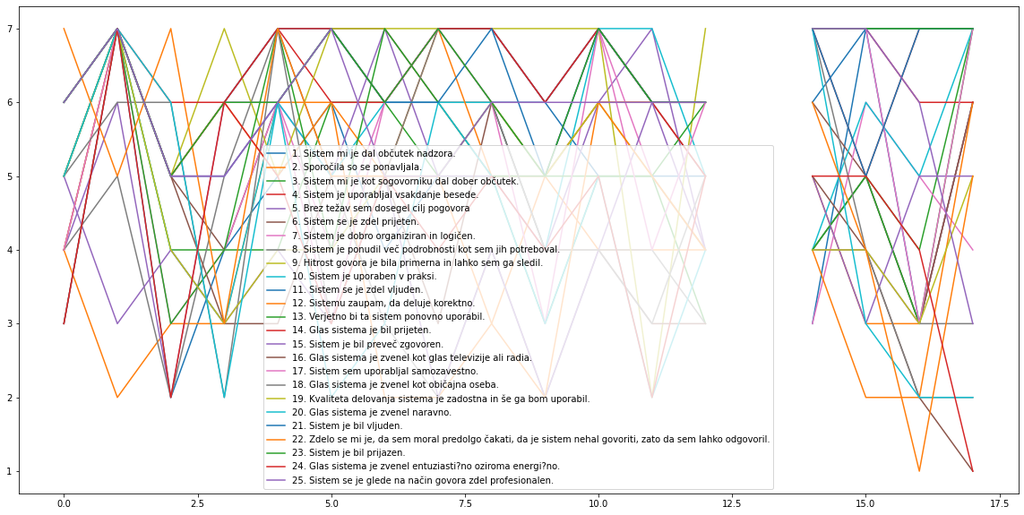

```python
# ---------------------------------------------------------------------------
# Load data
post_fn = 'https://raw.githubusercontent.com/andrejkk/UPK_DataImgs/master/2020-2021_PredPost-vprasalnik(dvogovor)(Responses).csv'
data_df = pd.read_csv(post_fn, header=0, sep=';', encoding='utf8')

#qs_weights_fn = 'https://raw.githubusercontent.com/andrejkk/UPK_DataImgs/master/QualityOfConvSys_Weights.cvs'
#qs_weights_df = pd.read_csv(qs_weights_fn, header=0, sep=';', encoding='utf8')

# Selectors
post_qs_inds = list(range(11,36))
anws_df = data_df.iloc[:, post_qs_inds]

# Plot answers
anws_df.plot(figsize=(20,10))



# Selectors
post_qs_inds = list(range(11,36))
data_qs_df = data_df.iloc[:, post_qs_inds].drop([13])


# Estimate latent variables
qa_mat = data_qs_df.to_numpy()
la_mat = qs_weights_df.to_numpy()
speech_quality_est_np = get_linear_scores_D(qa_mat, la_mat) # was data_qs_df.dot(qs_weights_df.to_numpy())

speech_quality_est_df = pd.DataFrame(speech_quality_est_np)
speech_quality_est_df.columns = ['UGO', 'CSB', 'SC', 'V']
```

```python
speech_quality_est_df
```

|  | UGO | CSB | SC | V |
| --- | --- | --- | --- | --- |
| 0 | 4.853537 | 7.253045 | 4.589716 | 5.720922 |
| 1 | 7.894977 | 8.849829 | 7.469081 | 4.299758 |
| 2 | 4.101955 | 6.485665 | 5.416353 | 4.592891 |
| 3 | 4.981673 | 7.122207 | 3.480377 | 3.991928 |
| 4 | 6.244843 | 7.911545 | 6.045799 | 6.888554 |
| 5 | 5.489269 | 8.688886 | 3.481940 | 5.452690 |
| 6 | 6.627815 | 7.772555 | 4.938018 | 4.262197 |
| 7 | 6.633079 | 8.240227 | 5.788867 | 3.173767 |
| 8 | 6.250908 | 8.380347 | 6.104369 | 3.973147 |
| 9 | 5.075979 | 7.298321 | 4.137158 | 3.144373 |
| 10 | 6.851058 | 8.527031 | 5.016507 | 5.155479 |
| 11 | 6.253142 | 6.919158 | 2.768151 | 5.392269 |
| 12 | 5.523420 | 7.416255 | 4.792375 | 4.273219 |
| 13 | 4.756360 | 8.510960 | 6.813860 | 5.711121 |
| 14 | 5.830594 | 7.913581 | 4.394088 | 4.289958 |
| 15 | 3.898820 | 7.847936 | 2.738084 | 3.358306 |
| 16 | 7.080362 | 7.909053 | 1.738858 | 5.415132 |

```python
anws_df
groups = {}
groups['PC'] = [0, 1, 2, 3, 4, 5, 6, 7]
groups['Echo'] = [8, 9, 10, 11, 12, 13, 14, 15]
anws_df.iloc[groups['Echo']]
```

|  | 1. Sistem mi je dal občutek nadzora. | 2. Sporočila so se ponavljala. | 3. Sistem mi je kot sogovorniku dal dober občutek. | 4. Sistem je uporabljal vsakdanje besede. | 5. Brez težav sem dosegel cilj pogovora | 6. Sistem se je zdel prijeten. | 7. Sistem je dobro organiziran in logičen. | 8. Sistem je ponudil več podrobnosti kot sem jih potreboval. | 9. Hitrost govora je bila primerna in lahko sem ga sledil. | 10. Sistem je uporaben v praksi. | ... | 16. Glas sistema je zvenel kot glas televizije ali radia. | 17. Sistem sem uporabljal samozavestno. | 18. Glas sistema je zvenel kot običajna oseba. | 19. Kvaliteta delovanja sistema je zadostna in še ga bom uporabil. | 20. Glas sistema je zvenel naravno. | 21. Sistem je bil vljuden. | 22. Zdelo se mi je, da sem moral predolgo čakati, da je sistem nehal govoriti, zato da sem lahko odgovoril. | 23. Sistem je bil prijazen. | 24. Glas sistema je zvenel entuziasti?no oziroma energi?no. | 25. Sistem se je glede na način govora zdel profesionalen. |
| --- | --- | --- | --- | --- | --- | --- | --- | --- | --- | --- | --- | --- | --- | --- | --- | --- | --- | --- | --- | --- | --- |
| 8 | 6.0 | 3.0 | 5.0 | 7.0 | 5.0 | 6.0 | 5.0 | 4.0 | 7.0 | 6.0 | ... | 6.0 | 6.0 | 6.0 | 6.0 | 5.0 | 7.0 | 3.0 | 6.0 | 5.0 | 6.0 |
| 9 | 6.0 | 5.0 | 3.0 | 6.0 | 4.0 | 5.0 | 5.0 | 2.0 | 7.0 | 4.0 | ... | 4.0 | 3.0 | 4.0 | 5.0 | 3.0 | 5.0 | 2.0 | 5.0 | 4.0 | 6.0 |
| 10 | 5.0 | 4.0 | 5.0 | 7.0 | 6.0 | 6.0 | 7.0 | 4.0 | 7.0 | 7.0 | ... | 4.0 | 7.0 | 4.0 | 6.0 | 5.0 | 7.0 | 6.0 | 7.0 | 5.0 | 6.0 |
| 11 | 5.0 | 4.0 | 5.0 | 6.0 | 7.0 | 6.0 | 5.0 | 4.0 | 2.0 | 7.0 | ... | 3.0 | 4.0 | 3.0 | 5.0 | 2.0 | 6.0 | 5.0 | 6.0 | 2.0 | 6.0 |
| 12 | 5.0 | 4.0 | 3.0 | 6.0 | 4.0 | 5.0 | 4.0 | 3.0 | 7.0 | 5.0 | ... | 3.0 | 6.0 | 5.0 | 4.0 | 4.0 | 6.0 | 4.0 | 6.0 | 5.0 | 6.0 |
| 13 | NaN | NaN | NaN | NaN | NaN | NaN | NaN | NaN | NaN | NaN | ... | NaN | NaN | NaN | NaN | NaN | NaN | NaN | NaN | NaN | NaN |
| 14 | 3.0 | 5.0 | 4.0 | 7.0 | 4.0 | 6.0 | 3.0 | 4.0 | 7.0 | 4.0 | ... | 5.0 | 7.0 | 7.0 | 4.0 | 7.0 | 7.0 | 6.0 | 7.0 | 5.0 | 7.0 |
| 15 | 7.0 | 3.0 | 5.0 | 5.0 | 4.0 | 5.0 | 6.0 | 5.0 | 7.0 | 6.0 | ... | 4.0 | 7.0 | 4.0 | 4.0 | 3.0 | 5.0 | 4.0 | 7.0 | 5.0 | 7.0 |

8 rows × 25 columns

```python
# one-way ANOVA fixed factor
#speech_quality_est

## ANOVA
import pandas as pd
from scipy.stats import f


latent_fs = ['UGO', 'CSB', 'SC', 'V']
groups = {}
groups['PC'] = [0, 1, 2, 3, 4, 5, 6, 7]
groups['Echo'] = [8, 9, 10, 11, 12, 13, 14, 15]

# For all vars
for fs_n in latent_fs:

    # Select groups
    sq_est_PC = speech_quality_est_df[fs_n][groups['PC']]
    sq_est_Echo = speech_quality_est_df[fs_n][groups['Echo']]

    # Compute SS
    curr_df = pd.DataFrame([np.array(sq_est_PC), np.array(sq_est_Echo)])
    SS_trt, SS_err, SS_T = get_ANOVA_SS(curr_df)


    # F-stat
    a,n = data_df.shape
    N = a*n
    F_0 = (SS_trt/(a-1)) / (SS_err/(N-a))

    # P-value
    p_val = 1-f.cdf(F_0, a-1, N-a)

    # Report
    print ('Latent var:', fs_n, 'p-val=', p_val)

    # Interpretation
    #  - Accept H0 for UGO, CSB and V: no significant difference among PC and Alexa box
    #  - Reject H0 for SC: there is a difference in speech characteristics
```

```
Latent var: UGO p-val= 0.7125751351732583
Latent var: CSB p-val= 0.999999847260303
Latent var: SC p-val= 0.039725795730025215
Latent var: V p-val= 0.12610459194099766
```